# オープンデータによる商店街通行量の可視化

高松市の例

[岩田真一郎](https://shinichiro-iwata.github.io/)（ [神奈川大学経済学部](https://www.econ.kanagawa-u.ac.jp/)）

2022-07-06作成，2025-03-08改訂

# 1 目的

官民データ活用推進基本法（2016年）において，地方自治体はオープンデータに取り組むことが義務付けられた．オープンデータの活用により地方自治体の課題解決や活性化が期待されている．

- [デジタル庁](https://www.digital.go.jp/)の[オープンデータ](https://www.digital.go.jp/resources/open_data/)参照．
- ここでは，香川県高松市の[オープンデータたかまつ](https://opendata-portal.smartcity-takamatsu.jp/)から商店街通行量情報をダウンロードし，可視化．
- データ変更に伴い，`R`コード改訂．

**通行量調査地点周辺地図** [^1]

[interactive chart not shown]

パッケージ：`sf`，`tidyverse`，`ggspatial`

```r
library(sf)
library(tidyverse)

#OpenStreetMap利用のため
library(ggspatial)
```

# 2 オープンデータ

## 2.1 オープンデータのダウンロード

- [オープンデータたかまつ](https://opendata.smartcity-takamatsu.jp/odp/) > データセット > 交通 > 商店街通行量情報 > data.csv （アクセス日：2024-03-16）[^2]
- `read.csv()`でデータ読込．文字化け防止のため，`fileEncoding="utf8"`を指示．オブジェクトを`pedestrian_traffic`とする．

```r
pedestrian_traffic<-
  read.csv("data.csv", fileEncoding="utf8")
```

**データの加工1**

- 平日及び休日の平均歩行者数を計算する．歩行者数は男女で分かれているため足し合わせる．
  - `mutate()`を用いて，新しい列を追加．

```r
pedestrian_traffic %>%
  mutate("平日"=manWeekdaysAverage+womanWeekdaysAverage,
         "休日"=manHolidayAverage+womanHolidayAverage) ->
  pedestrian_traffic
```

## 2.2 `sf`クラス

- `st_as_sf()`を利用して，`sf`クラスのデータ作成．
  - 座標参照系（`crs`）は日本測地系JGD2011 （`EPSG:6668`）を指示．
  - [7 地理データの再投影](http://124.219.182.167/geo/reproj-geo-data.html)参照．

```r
pedestrian_traffic %>%
  st_as_sf(coords=c("longitude", "latitude"),
           crs="EPSG:6668") ->
  pedestrian_traffic
```

**作成したデータの中身確認と歩行者数の可視化**

- データの中身（最初の6行）を確認．
  - データ（データフレーム）は横方向にまとめられた**ワイドフォーマット**．
  - 必要な変数を抽出し，中身を確認．
  - `Geometry type`がポイント（`POINT`），`CRS`が`JGD2011`であることが確認できる．

```r
pedestrian_traffic %>%
  select(name, 平日, 休日) %>%
  head()
```

```
## Simple feature collection with 6 features and 3 fields
## Geometry type: POINT
## Dimension:     XY
## Bounding box:  xmin: 134.0474 ymin: 34.34566 xmax: 134.0534 ymax: 34.34656
## Geodetic CRS:  JGD2011
##             name  平日  休日                  geometry
## 1   兵庫町（西）  4626  3536 POINT (134.0474 34.34656)
## 2   兵庫町（東）  8671  9667 POINT (134.0503 34.34612)
## 3 片原町西（西） 10294 14154 POINT (134.0506 34.34624)
## 4 片原町西（東）  5718  7126 POINT (134.0508 34.34605)
## 5 片原町東（西）  3328  3439 POINT (134.0534 34.34566)
## 6   丸亀町（北） 10200 15044 POINT (134.0505 34.34594)
```

とりあえず，平日の歩行者数を可視化．

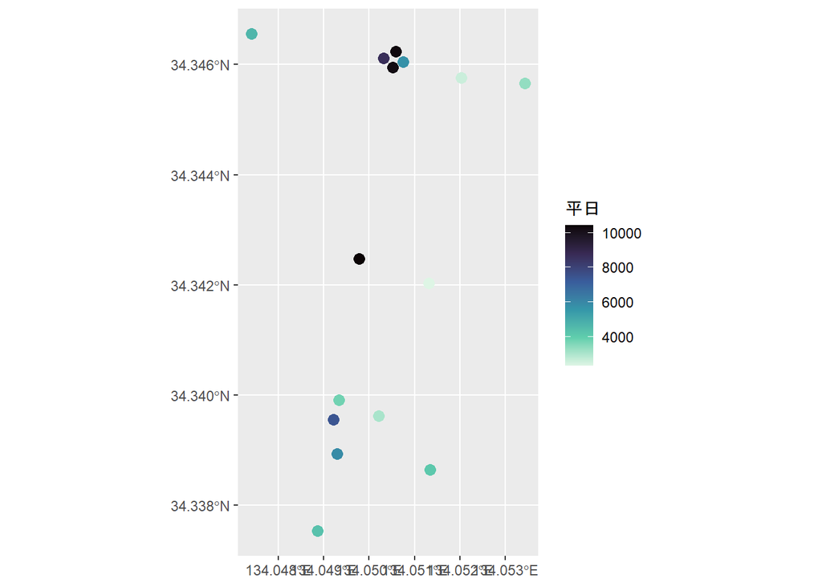

```r
ggplot()+
  geom_sf(data=pedestrian_traffic,
          aes(color=平日), size=3)+
  scale_color_viridis_c(option="G", direction=-1)
```

**データの加工2（ワイド→ロング）**

平日と休日の違いをわかりやすくするためにデータを加工.

- 複数の地図の並べ方を指示できる`facet_wrap()`が比較のためには有効．
  - このためには，平日と休日の歩行者数を現在のような横方向に並べるのではなく，縦方向に並び変える必要がある．
  - 縦方向にまとめられたデータ（データフレーム）は**ロングフォーマット**とよばれる．
- `gather()`：ワイドフォーマットをロングフォーマットに変更．
- `day`と名付けた列を新しくつくる（`key=day`）．`day`の列で平日と休日を識別する．
- 平日の歩行者と休日の歩行者数を一つの列（`pt`と名付ける）にまとめる．
  - `value=pt`の後に縦方向に並ばせたい列名（ここでは「平日」，「休日」）を記入．
  - 作成したデータを`pedestrian_traffic1`と名付ける．
  - [9 データハンドリング](https://datareporting.kirikuroda.com/data-handling.html)（アクセス日：2022-07-08） を参照した．

```r
pedestrian_traffic %>%
  gather(key=day, value=pt, "平日", "休日") ->
  pedestrian_traffic1
```

**作成したデータの中身確認**

- 中身を確認し易いように，ここでは3列だけ抽出．オブジェクトを`pedestrian_traffic2`とする．

```r
pedestrian_traffic1 %>%
  select(day, pt, geometry) ->
  pedestrian_traffic2
```

- `head()`と`tail()`を用いて，最初の6行と最後の6行を表示．
  - ロングフォーマットに変更されたことを確認．

```r
#最初の6行
pedestrian_traffic2 %>%
  head()
```

```
## Simple feature collection with 6 features and 2 fields
## Geometry type: POINT
## Dimension:     XY
## Bounding box:  xmin: 134.0474 ymin: 34.34566 xmax: 134.0534 ymax: 34.34656
## Geodetic CRS:  JGD2011
##    day    pt                  geometry
## 1 平日  4626 POINT (134.0474 34.34656)
## 2 平日  8671 POINT (134.0503 34.34612)
## 3 平日 10294 POINT (134.0506 34.34624)
## 4 平日  5718 POINT (134.0508 34.34605)
## 5 平日  3328 POINT (134.0534 34.34566)
## 6 平日 10200 POINT (134.0505 34.34594)
```

```r
#最後の6行
pedestrian_traffic2 %>%
  tail()
```

```
## Simple feature collection with 6 features and 2 fields
## Geometry type: POINT
## Dimension:     XY
## Bounding box:  xmin: 134.0489 ymin: 34.33753 xmax: 134.0513 ymax: 34.33991
## Geodetic CRS:  JGD2011
##     day   pt                  geometry
## 25 休日 9784 POINT (134.0492 34.33956)
## 26 休日 7874 POINT (134.0493 34.33893)
## 27 休日 5264 POINT (134.0513 34.33865)
## 28 休日 3819 POINT (134.0489 34.33753)
## 29 休日 1870 POINT (134.0502 34.33962)
## 30 休日 4282 POINT (134.0493 34.33991)
```

# 3 完成図

「平日」，「休日」の順番に並べたいが，何も指示しないと「休日」，「平日」の順番になってしまう．意図した順番と異なり，意図したい順番に並べ替えたい場合は，`factor()`を利用．

- `factor()`で順番を「平日」，「休日」に指定．
  - [14. データハンドリング［基礎編: factor型］](https://www.jaysong.net/RBook/factor.html)（アクセス日：2022-07-08）を参照した．

```r
#必要に応じて，並び替え
pedestrian_traffic1 %>%
  mutate(day=factor(day, levels=c("平日", "休日"))) ->
  pedestrian_traffic1
```

背景としてOpenStreetMap（OSM）を利用．

- OSM利用に関しては[OpenStreetMapを背景にした情報通信業事業所数の可視化](https://shinichiro-iwata.github.io/geospatial-data-visualization/economic-census-visualization.html)参照．
  - `annotation_map_tile()`：背景にOSMのタイルを使う．
  - `labs()`に出典を記入．
  - `coord_sf()`：座標参照系を設定．設定しなくても問題はないが，設定したことにより背景の地図が鮮明になった．
  - `facet_wrap()`：複数の地図の並べ方を指示．
    - `~day`：平日と休日の地図を作成．
    - `ncol=2`：1行に地図を2枚並列．
  - キャプション（`plot.caption`）は左寄せ．
  - 文字サイズ（`text`）を拡大（`size=12`）．
  - `annotation_scale()`：スケール（縮尺）・バーの表示．位置と形状を支持．

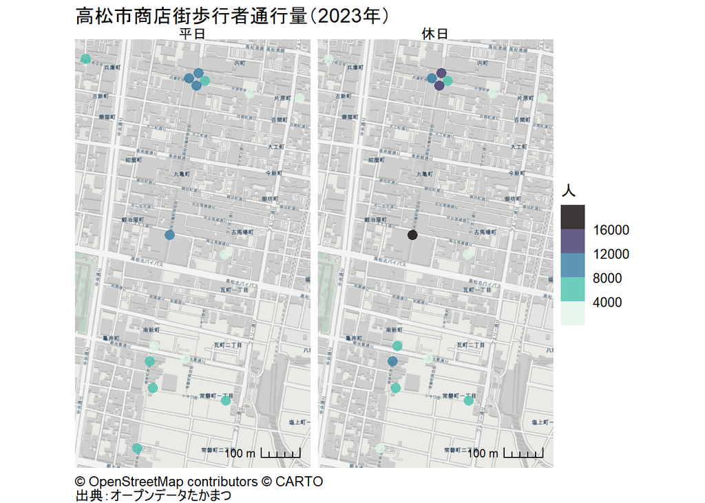

```r
ggplot()+
  annotation_map_tile(type="cartolight",
                      zoomin=0)+
  geom_sf(data=pedestrian_traffic1,
          aes(color=pt), size=3)+
  scale_color_viridis_b(option="G",
                        direction=-1,
                        alpha=0.8)+
  facet_wrap(~day, ncol=2)+
  labs(color="人",
       caption="\U00a9 OpenStreetMap contributors \U00a9 CARTO
出典：オープンデータたかまつ")+
  ggtitle("高松市商店街歩行者通行量（2023年）")+
  annotation_scale(location="br", style="ticks")+
  coord_sf(crs="EPSG:6668")+
  theme_void()+
  theme(plot.caption=element_text(hjust=0),
        text=element_text(size=12))
```

# 4 応用

- `↑`の地図をバブルマップで作成．
  - バブルマップの作成方法は[バブルマップによる地価の可視化](https://shinichiro-iwata.github.io/geospatial-data-visualization/bubble-map-visualization.html)を参照．
  - ここでは，`st_coordinates()`で座標を再取得するように指示．
    - 括弧内の1番目の数値（経度）を`x`，2番目の数値（緯度）を`y`とするように指示．
  - **ポイント**：`coord_sf()`：座標参照系を設定しなかった場合，背景地図が示されなかった．このため**設定**．

```r
#もとのデータで作業
pedestrian_traffic1 %>%
  mutate(x=st_coordinates(geometry)[, 1],
         y=st_coordinates(geometry)[, 2]) ->
  pedestrian_traffic
```

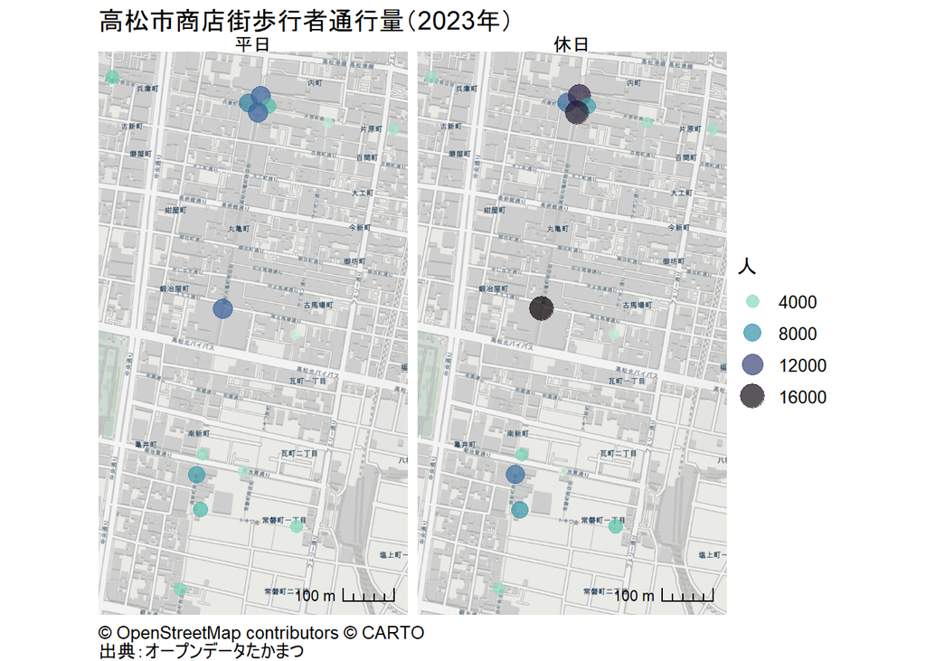

```r
ggplot()+
  annotation_map_tile(type="cartolight",
                      zoomin=0)+
  geom_point(data=pedestrian_traffic,
             aes(x=x, y=y,
              color=pt,
              size=pt))+
  scale_color_viridis_c(option="G",
                      direction=-1,
                      guide="legend",
                      alpha=0.7)+
  scale_size_area(max_size=6)+
  facet_wrap(~day, ncol=2)+
  labs(color="人", size="人",
       x="", y="",
       caption="\U00a9 OpenStreetMap contributors \U00a9 CARTO
出典：オープンデータたかまつ")+
  ggtitle("高松市商店街歩行者通行量（2023年）")+
  annotation_scale(location="br", style="ticks")+
  coord_sf(crs="EPSG:6668")+
  theme_void()+
  theme(plot.caption=element_text(hjust=0),
        text=element_text(size=12))
```

**Rによる地理空間データの可視化**

- チュートリアル[ホーム](https://shinichiro-iwata.github.io/geospatial-data-visualization/)
[^1]: この地図は`mapview()`を用いた作成．`mapview()`地理空間データの可視化については[インタラクティブな地図によるデータの可視化](https://shinichiro-iwata.github.io/geospatial-data-visualization/interactive-map-visualization.html)参照．
[^2]: 作成日（2022-07-06）時点では2021年の商店街通行量情報がテキストファイルとEXCELファイルであったが，改定時（2024-03-16）は2023年の商店街通行量情報がcsvファイルとGeoJSONファイルに変更された模様．